# Bootstrapping and Simple Simulations

John Ashley Burgoyne

This tutorial assumes that you have loaded the Paradiso dataset into R.

# Bootstrapping

Bootstrapping is a very simple way to get a sense of sampling error even without a model. Advanced statisticians also use it when models get too complicated to use the model-based simulations described below.

## 1. Re-sample Your Data

The key idea of bootstrapping is that you resample a data set of the same size as your original data set by drawing out of your original data *with replacement*. We can do that in R with the `sample()` command. It needs to know the name of the *variable* you want to resample in R, the number of observations, and whether you want to use replacement.

We can see from the Environment tab (top-right) that the Paradiso dataset has 545 observations and for bootstrapping, we do want replacement. Let’s look at the country of origin of the performers (`paradiso$herkomst`).

```r
new_herkomst <- sample(paradiso$herkomst, 545, replace = TRUE)
new_herkomst
```

```
##   [1] "Engeland"             "Engeland"             "Duitsland"
##   [4] "Nederland"            "Duitsland"            "Nederland, Belgie"
##   [7] "Kameroen"             "Verenigde Staten"     "Nederland"
##  [10] "Verenigde Staten"     "Nederland"            "Verenigde Staten"
##  [13] "Verenigde Staten"     "Engeland"             "Engeland"
##  [16] "Nederland"            "Nederland"            "Schotland"
##  [19] "Nederland"            "Verenigde Staten"     "Nederland"
##  [22] "Nederland"            "Engeland"             "Engeland"
##  [25] "Schotland"            "Engeland"             "Nederland"
##  [28] "Verenigde Staten"     "Engeland"             "Engeland"
##  [31] "België"               "Verenigde Staten"     "Nederland"
##  [34] "Verenigde Staten"     "Zweden"               "Verenigde Staten"
##  [37] "Nederland"            "Verenigde Staten"     "Verenigde Staten"
##  [40] "Verenigde Staten"     "Verenigde Staten"     "Duitsland"
##  [43] "Verenigde Staten"     "Verenigde Staten"     "Verenigde Staten"
```

[output cut: 167 more lines]

## 2. Choose a Statistic

When bootstrapping, we need to choose the **statistic** that we care about. This can be any quantity of interest. Let’s get a sense of how many acts who peform at Paradiso are Dutch.

We can use the `table()` command to count discrete variables.

```r
table(paradiso$herkomst)
```

```
##
##                   Alaska                 Algarije               Argentinie
##                        1                        1                        2
##                Australie                Australië                   Belgie
##                        4                        1                        3
##                   België Belgie, Verenigde Staten                 Brazilië
##                        5                        1                        2
##                Bulgarije                   Canada                    Congo
##                        1                       12                        2
##                     Cuba               Denemarken                Duitsland
##                        4                        2                       10
##                 Engeland                 Engelend                  Estland
##                      118                        1                        1
##                  Finland                Frankrijk              Griekenland
##                        1                        5                        2
##                Hongarije                  Ierland                  IJsland
##                        3                        8                        2
##                    India                   Italie                  Jamaica
##                        1                        4                       12
##                    Japan                 Kameroen                  Libanon
##                        1                        1                        1
##                Nederland        Nederland, Belgie            Nieuw Zeeland
##                      104                        1                        1
##                  Nigeria            Noord Ierland                 Norwegen
##                        2                        1                        1
##                 Pakistan                    Polen                 Portugal
##                        2                        1                        2
##                  Rusland                Schotland                  Senegal
##                        1                       11                        3
##       Trinidad en Tobago                  Turkije           Tuva (Rusland)
##                        1                        2                        1
##                       UK     Verenigd Koningkrijk         Verenigde Staten
##                        1                        1                      184
##                    Wales              Zuid-Afrika                   Zweden
##                        1                        2                        9
##              Zwitserland
##                        1
```

We can use this `table()` trick to get bar charts of discrete variables!

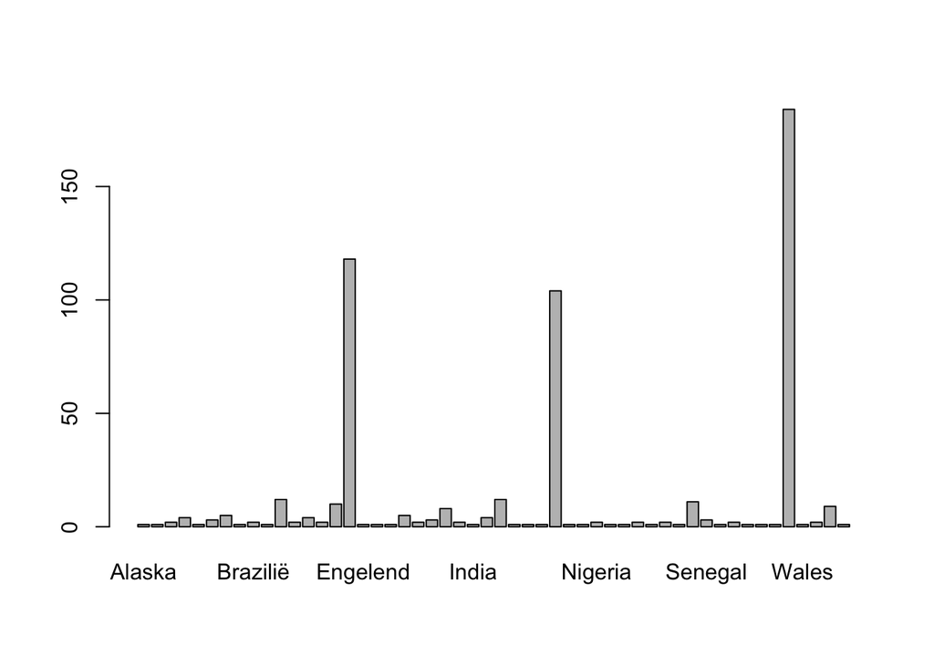

```r
barplot(table(paradiso$herkomst))
```

If we only want *one* of these counts, we use square brackets and quotation marks like this. There are 104 acts from the Netherlands in the original data.

```r
table(paradiso$herkomst)["Nederland"]
```

```
## Nederland
##       104
```

```r
table(paradiso$herkomst)["Nederland"] / 454
```

```
## Nederland
## 0.2290749
```

We can do the same thing with our re-sampled `new_paradiso` dataset. The value of the statistic is close, but not exactly the same.

```r
table(new_herkomst)["Nederland"] / 454
```

```
## Nederland
## 0.2511013
```

## 3. Replicate

Bootstrapping requires use to repeat this procedure many times. We can do that with the `replicate()` command. Notice that we need to use curly brackets and *not* give our last line with a variable name.

Usually we replicate many times for a bootstrap: 1000 or more times is common.

```r
bootstrap <- replicate(1000, {
  new_herkomst <- sample(paradiso$herkomst, 454, replace = TRUE)
  table(new_herkomst)["Nederland"] / 454
})
```

## 4. Visualise the Output

Now we can look at a histogram to get a sense of how certain we are about the percentage of Dutch acts based on our observations.

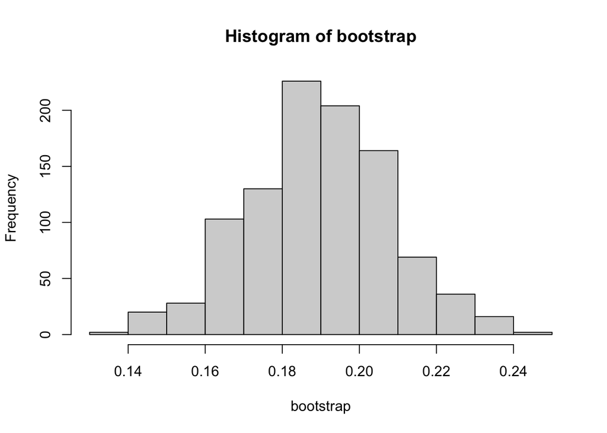

```r
hist(bootstrap)
```

# Model-Based Simulation

For model-based simulation, we use a model instead.

## Normal Distribution

Let’s look at the number of performances of Paradiso acts, and use a normal distribution based on the actual mean and standard deviation. We can compute these with the built-in `mean()` and `sd()` functions.

```r
mean(paradiso$optredens)
```

```
## [1] 4.73945
```

```r
sd(paradiso$optredens)
```

```
## [1] 6.724489
```

We make a new sample of 454 with `rnorm()`

```r
new_optredens <- rnorm(454, mean = 4.73945, sd = 6.724489)
```

Just like bootstrapping, we need to choose a statistics that interests us. Let’s use the average (mean) number of performances. Let’s look at the mean of our model-based sample. Like our bootstrapping example, it is similar, but not exactly the same, as the mean of our data

```r
mean(new_optredens)
```

```
## [1] 4.83985
```

Just like the bootstrap, we can replicate this procedure many times.

```r
model_based <- replicate(1000, {
  new_optredens <- 4.73945 + rnorm(454, sd = 6.724489)
  mean(new_optredens)
})
```

And again, look at a histogram or compute statistics.

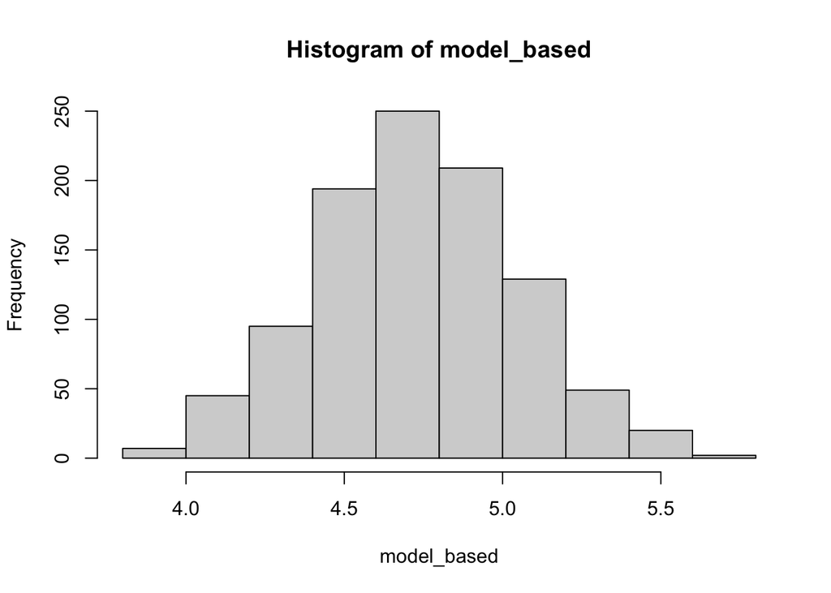

```r
hist(model_based)
```

## Binomial Distribution

If we are interested in doing model-based simulation of a discrete variable, we can use `rbinom()` instead of `rnorm()`. Let’s try it with the previous example. Instead of bootstrapping samples of `herkomst`, let’s use a binomial distribution.

```r
table(paradiso$herkomst)["Nederland"] / 454
```

```
## Nederland
## 0.2290749
```

To compute a binomial distribution, we use `rbinom()` with three arguments: - the number of observations we want in our new simulation, - a fixed value of 1, and - the proportion we expect.

```r
new_herkomst <- rbinom(454, 1, 0.2290749)
new_herkomst
```

```
##   [1] 0 0 0 0 1 0 0 0 0 0 1 0 0 0 0 0 0 1 0 0 1 0 1 0 0 1 1 1 0 0 0 1 1 0 0 1 1
##  [38] 0 0 0 0 0 1 0 0 0 0 0 1 0 0 1 0 0 1 0 0 0 0 0 0 0 0 0 1 1 0 1 1 0 0 0 0 0
##  [75] 0 0 0 1 0 0 0 0 0 0 0 1 1 0 0 0 1 0 0 0 0 1 0 0 0 0 0 1 0 1 0 0 1 1 0 0 1
## [112] 0 0 0 0 0 0 0 0 1 0 0 0 0 0 1 0 1 0 0 0 0 0 0 1 0 0 0 0 0 0 1 1 0 0 0 0 0
## [149] 1 0 1 0 0 0 0 0 1 0 1 1 0 0 0 0 0 0 0 0 0 0 0 0 1 0 1 0 0 1 0 0 0 0 0 0 0
## [186] 0 1 0 0 0 0 0 1 1 0 1 0 0 0 0 1 1 0 0 0 0 0 0 0 0 0 0 0 0 1 0 1 0 1 0 0 0
## [223] 1 1 0 0 0 0 0 1 0 0 0 0 0 0 0 0 1 0 0 1 1 0 0 0 0 0 0 0 1 0 0 1 0 1 0 1 0
## [260] 1 0 0 0 0 1 0 1 1 1 0 0 1 0 0 1 0 0 0 0 0 0 0 1 0 0 0 1 0 0 0 0 0 0 0 0 1
## [297] 1 0 0 0 0 0 0 0 1 0 1 0 1 1 1 1 0 0 0 0 0 1 0 0 0 0 1 0 0 0 0 0 0 0 0 0 0
## [334] 0 1 1 0 1 0 0 0 0 0 0 0 1 0 0 0 0 0 0 0 0 1 1 0 0 0 1 1 1 0 0 0 0 0 1 0 1
## [371] 0 1 0 1 0 0 0 0 0 0 1 0 0 0 0 1 0 0 0 0 1 0 0 0 0 0 0 1 0 0 0 0 0 1 0 0 0
## [408] 0 0 0 0 0 0 1 1 1 1 0 0 0 0 0 1 0 0 0 0 0 0 1 0 0 1 0 0 0 0 0 0 1 0 1 1 0
## [445] 0 0 0 0 0 0 0 0 0 0
```

Notice that `rbinom()` just gives use zeros and ones. Each 1 means refers to a ‘true’ or ‘yes’ response – in this case, a Dutch performer. Each 0 refers to a ‘false’ or ‘no’ response – in this case, a non-Dutch performer. If we take the average of these zeros and ones, we get the proportion of Dutch performers in our sample.

```r
mean(new_herkomst)
```

```
## [1] 0.2422907
```

Again, this is close to the proportion in the original data, but not exactly the same.

Just as the previous two examples, we now replicate the entire thing a large number of times.

```r
model_based <- replicate(1000, {
  new_herkomst <- rbinom(454, 1, 0.2290749)
  mean(new_herkomst)
})
```

And we can look at a histogram of the results to see what the model-based range of possible proportions would be, based on the data we observed. How does it compare to the bootstrap version?

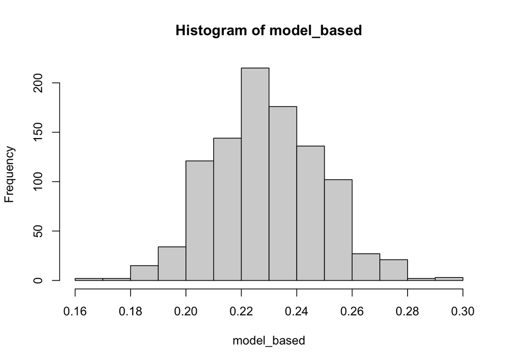

```r
hist(model_based)
```

# Recommended Exercises

- Compute a *bootstrap* estimate of the average number of performances in the Paradiso dataset? How does the histogram compare to the model-based histogram? Why do you think it looks the same/different?
- Choose a different dataset and choose a statistic of interest. For most research questions, that will be either the mean of a continuous variable or the proportion of one category of a discrete variable, like the examples here. Run a bootstrap and a model-based simulation of these statistics and compare the resulting histograms.